# Projet 2 : VaR et backtesting, Action UNH

#### Avec la distribution nig:

```r
spec_igarch2 <- ugarchspec(variance.model=list(model="iGARCH", garchOrder=c(1,1)),
           mean.model=list(armaOrder=c(1,1),external.regressors=as.matrix(cbind(mardi,juillet))),
           distribution.model="nig",
           fixed.pars = list(skew = 0))
fit_igarch2 <- ugarchfit(spec = spec_igarch2, data = rt, out.sample = length(rtt), solver = "hybrid")
show(fit_igarch2)
```

```
*---------------------------------*
*          GARCH Model Fit        *
*---------------------------------*

Conditional Variance Dynamics
-----------------------------------
GARCH Model : iGARCH(1,1)
Mean Model  : ARFIMA(1,0,1)
Distribution    : nig

Optimal Parameters
------------------------------------
        Estimate  Std. Error   t value Pr(>|t|)
mu      0.000992    0.000205   4.84030 0.000001
ar1     0.910118    0.020425  44.55845 0.000000
ma1    -0.947644    0.017401 -54.45874 0.000000
mxreg1  0.000842    0.000639   1.31703 0.187828
mxreg2 -0.000282    0.000682  -0.41295 0.679645
omega   0.000000    0.000000   0.97062 0.331736
alpha1  0.033720    0.003676   9.17194 0.000000
beta1   0.966280          NA        NA       NA
skew    0.000000          NA        NA       NA
shape   1.117996    0.160872   6.94959 0.000000

Robust Standard Errors:
        Estimate  Std. Error   t value Pr(>|t|)
mu      0.000992    0.000205   4.83662 0.000001
ar1     0.910118    0.018905  48.14059 0.000000
ma1    -0.947644    0.013943 -67.96385 0.000000
mxreg1  0.000842    0.000656   1.28231 0.199736
mxreg2 -0.000282    0.000741  -0.38011 0.703861
omega   0.000000    0.000001   0.56825 0.569868
alpha1  0.033720    0.013663   2.46800 0.013587
beta1   0.966280          NA        NA       NA
skew    0.000000          NA        NA       NA
shape   1.117996    0.166491   6.71507 0.000000

LogLikelihood : 5899.217

Information Criteria
```

[output cut: 52 more lines]

```
Negative Sign Bias  1.1371 0.2556
Positive Sign Bias  0.7032 0.4820
Joint Effect        1.7927 0.6165


Adjusted Pearson Goodness-of-Fit Test:
------------------------------------
  group statistic p-value(g-1)
1    20     24.89     0.164168
2    30     37.22     0.140598
3    40     56.01     0.038042
4    50     76.24     0.007618


Elapsed time : 0.778157
```

```r
spec_igarch2 <- ugarchspec(variance.model=list(model="iGARCH", garchOrder=c(1,1)),
           mean.model=list(armaOrder=c(1,1)),distribution.model="nig",
           fixed.pars = list(skew = 0))
fit_igarch2 <- ugarchfit(spec = spec_igarch2, data = rt, out.sample = length(rtt), solver = "hybrid")
show(fit_igarch2)
```

```
*---------------------------------*
*          GARCH Model Fit        *
*---------------------------------*

Conditional Variance Dynamics
-----------------------------------
GARCH Model : iGARCH(1,1)
Mean Model  : ARFIMA(1,0,1)
Distribution    : nig

Optimal Parameters
------------------------------------
        Estimate  Std. Error  t value Pr(>|t|)
mu      0.001136    0.000146   7.8012  0.00000
ar1     0.909752    0.020720  43.9072  0.00000
ma1    -0.947243    0.017703 -53.5078  0.00000
omega   0.000000    0.000000   0.9680  0.33305
alpha1  0.033753    0.003693   9.1404  0.00000
beta1   0.966247          NA       NA       NA
skew    0.000000          NA       NA       NA
shape   1.107832    0.159068   6.9645  0.00000

Robust Standard Errors:
        Estimate  Std. Error   t value Pr(>|t|)
mu      0.001136    0.000147   7.75508 0.000000
ar1     0.909752    0.018938  48.03914 0.000000
ma1    -0.947243    0.013896 -68.16890 0.000000
omega   0.000000    0.000001   0.56181 0.574243
alpha1  0.033753    0.013788   2.44810 0.014361
beta1   0.966247          NA        NA       NA
skew    0.000000          NA        NA       NA
shape   1.107832    0.165304   6.70178 0.000000

LogLikelihood : 5898.265

Information Criteria
------------------------------------

Akaike       -5.8484
Bayes        -5.8317
```

[output cut: 46 more lines]

```
Negative Sign Bias  1.1257 0.2604
Positive Sign Bias  0.6836 0.4943
Joint Effect        1.7397 0.6281


Adjusted Pearson Goodness-of-Fit Test:
------------------------------------
  group statistic p-value(g-1)
1    20     26.90      0.10710
2    30     41.00      0.06880
3    40     48.34      0.14505
4    50     64.93      0.06335


Elapsed time : 0.5254989
```

**Ce modèle est un bon candidat pour l’estimation de la VaR de nos rendements.**

### GJR-GARCH(0,1):

Cliquez pour revenir à la partie concernée

```r
spec_gjrgarch <- ugarchspec(variance.model=list(model="gjrGARCH", garchOrder=c(1,1)),
           mean.model=list(armaOrder=c(1,1),external.regressors=as.matrix(cbind(mardi,juillet))),
           distribution.model="std")
fit_gjrgarch <- ugarchfit(spec = spec_gjrgarch, data = rt, out.sample = length(rtt), solver = "hybrid")
show(fit_gjrgarch)
```

```
*---------------------------------*
*          GARCH Model Fit        *
*---------------------------------*

Conditional Variance Dynamics
-----------------------------------
GARCH Model : gjrGARCH(1,1)
Mean Model  : ARFIMA(1,0,1)
Distribution    : std

Optimal Parameters
------------------------------------
        Estimate  Std. Error   t value Pr(>|t|)
mu      0.000910    0.000213   4.27932 0.000019
ar1     0.908892    0.020882  43.52603 0.000000
ma1    -0.944702    0.018322 -51.56118 0.000000
mxreg1  0.000987    0.000636   1.55241 0.120565
mxreg2 -0.000286    0.000671  -0.42611 0.670024
omega   0.000002    0.000002   0.87809 0.379896
alpha1  0.014757    0.007015   2.10368 0.035406
beta1   0.955425    0.008962 106.60562 0.000000
gamma1  0.044637    0.015085   2.95901 0.003086
shape   4.959350    0.753366   6.58292 0.000000

Robust Standard Errors:
        Estimate  Std. Error   t value Pr(>|t|)
mu      0.000910    0.000207   4.39929 0.000011
ar1     0.908892    0.015453  58.81551 0.000000
ma1    -0.944702    0.011411 -82.78865 0.000000
mxreg1  0.000987    0.000612   1.61244 0.106867
mxreg2 -0.000286    0.000625  -0.45747 0.647331
omega   0.000002    0.000012   0.14558 0.884251
alpha1  0.014757    0.021938   0.67269 0.501146
beta1   0.955425    0.047638  20.05583 0.000000
gamma1  0.044637    0.054697   0.81608 0.414457
shape   4.959350    3.240623   1.53037 0.125925

LogLikelihood : 5907.476

Information Criteria
```

[output cut: 54 more lines]

```
Negative Sign Bias 0.69806 0.4852
Positive Sign Bias 1.31493 0.1887
Joint Effect       2.50898 0.4737


Adjusted Pearson Goodness-of-Fit Test:
------------------------------------
  group statistic p-value(g-1)
1    20     19.05       0.4533
2    30     32.13       0.3141
3    40     50.29       0.1063
4    50     52.57       0.3376


Elapsed time : 0.4225512
```

```r
spec_gjrgarch <- ugarchspec(variance.model=list(model="gjrGARCH", garchOrder=c(1,1)),
           mean.model=list(armaOrder=c(1,1)),distribution.model="std")
fit_gjrgarch <- ugarchfit(spec = spec_gjrgarch, data = rt, out.sample = length(rtt), solver = "hybrid")
show(fit_gjrgarch)
```

```
*---------------------------------*
*          GARCH Model Fit        *
*---------------------------------*

Conditional Variance Dynamics
-----------------------------------
GARCH Model : gjrGARCH(1,1)
Mean Model  : ARFIMA(1,0,1)
Distribution    : std

Optimal Parameters
------------------------------------
        Estimate  Std. Error   t value Pr(>|t|)
mu      0.001086    0.000155   7.01369 0.000000
ar1     0.908741    0.020860  43.56332 0.000000
ma1    -0.944509    0.018345 -51.48640 0.000000
omega   0.000002    0.000002   0.96685 0.333621
alpha1  0.015028    0.006585   2.28226 0.022474
beta1   0.956634    0.007163 133.55916 0.000000
gamma1  0.042550    0.013727   3.09972 0.001937
shape   4.921788    0.716299   6.87114 0.000000

Robust Standard Errors:
        Estimate  Std. Error   t value Pr(>|t|)
mu      0.001086    0.000154   7.06239 0.000000
ar1     0.908741    0.015285  59.45380 0.000000
ma1    -0.944509    0.011261 -83.87683 0.000000
omega   0.000002    0.000009   0.17747 0.859141
alpha1  0.015028    0.016646   0.90280 0.366634
beta1   0.956634    0.032879  29.09596 0.000000
gamma1  0.042550    0.039193   1.08563 0.277642
shape   4.921788    2.691402   1.82871 0.067443

LogLikelihood : 5906.182

Information Criteria
------------------------------------

Akaike       -5.8543
Bayes        -5.8320
```

[output cut: 48 more lines]

```
Negative Sign Bias 0.70882 0.4785
Positive Sign Bias 1.31172 0.1898
Joint Effect       2.47182 0.4804


Adjusted Pearson Goodness-of-Fit Test:
------------------------------------
  group statistic p-value(g-1)
1    20     22.67       0.2523
2    30     34.72       0.2138
3    40     56.21       0.0366
4    50     64.53       0.0676


Elapsed time : 0.627553
```

- **Robust Standard Errors :** On a ici *omega* qui n’est pas significatif, mais on ne peut pas le retirer. De plus, *alpha1* n’est pas significatif. On va donc le retirer :

```r
spec_gjrgarch <- ugarchspec(variance.model=list(model="gjrGARCH", garchOrder=c(1,1)),
           mean.model=list(armaOrder=c(1,1)),distribution.model="std",
           fixed.pars = list(alpha1 = 0))
fit_gjrgarch <- ugarchfit(spec = spec_gjrgarch, data = rt, out.sample = length(rtt), solver = "hybrid")
show(fit_gjrgarch)
```

```
*---------------------------------*
*          GARCH Model Fit        *
*---------------------------------*

Conditional Variance Dynamics
-----------------------------------
GARCH Model : gjrGARCH(1,1)
Mean Model  : ARFIMA(1,0,1)
Distribution    : std

Optimal Parameters
------------------------------------
        Estimate  Std. Error  t value Pr(>|t|)
mu      0.001081    0.000167   6.4886 0.000000
ar1     0.899617    0.023690  37.9745 0.000000
ma1    -0.933560    0.021496 -43.4286 0.000000
omega   0.000002    0.000001   1.9619 0.049776
alpha1  0.000000          NA       NA       NA
beta1   0.959226    0.003779 253.7978 0.000000
gamma1  0.061047    0.008501   7.1811 0.000000
shape   4.888639    0.563427   8.6766 0.000000

Robust Standard Errors:
        Estimate  Std. Error   t value Pr(>|t|)
mu      0.001081    0.000171   6.32665  0.00000
ar1     0.899617    0.020506  43.87154  0.00000
ma1    -0.933560    0.014656 -63.69596  0.00000
omega   0.000002    0.000004   0.61405  0.53918
alpha1  0.000000          NA        NA       NA
beta1   0.959226    0.006786 141.34799  0.00000
gamma1  0.061047    0.009810   6.22285  0.00000
shape   4.888639    0.837808   5.83503  0.00000

LogLikelihood : 5903.26

Information Criteria
------------------------------------

Akaike       -5.8524
Bayes        -5.8329
```

[output cut: 47 more lines]

```
Negative Sign Bias 0.75295 0.45157
Positive Sign Bias 1.87554 0.06086   *
Joint Effect       4.70562 0.19467


Adjusted Pearson Goodness-of-Fit Test:
------------------------------------
  group statistic p-value(g-1)
1    20     20.27       0.3788
2    30     36.51       0.1592
3    40     45.68       0.2142
4    50     59.12       0.1525


Elapsed time : 0.3475029
```

En retirant *alpha1* on a :

- **Robust Standard Errors :** Tous les coefficients sont significatifs sauf omega
- **Weighted Ljung-Box Test on Standardized Residuals :** Toutes les p-values sont supérieurs à 0.05. Il n’y a pas d’autocorrélation dans notre série.
- **Weighted ARCH LM Tests :** Toutes les p-values sont supérieurs à 0.05. Il n’y a pas d’effets ARCH dans notre série.
- **Nyblom stability Test :** Nos variables ne sont pas stable dans le temps, la statistiques de test jointe est beaucoup plus élevé que la valeur tabulée à 5%. 64,4084 > 1,9.
- **Sign bias Test :** Toutes les p-values sont supérieurs à 0.05. Il n’y pas d’effet de taille ni d’effet de signe.
- **Adjusted Pearson Goodness-of-Fit Test :** Toutes les p-values sont supérieurs à 0.05. On a la bonne distribution.

*On a ici un candidat potentielle*

### APARCH(1,1):

Commençons par estimer un APARCH(1,1), ce qui correspond au processus suivant :

- ARCH(1) quand $\delta = 2, \gamma_1 = \beta_1 = 0$
- GARCH(1,1) quand $\delta = 2, \gamma_1 = 0$
- GJR-GARCH(1,1) quand $\delta = 2$

Ce modèle est donc très interessant car d’autre modèles sont des cas particulier de celui ci.

```r
spec_aparch <- ugarchspec(variance.model = list(model = "apARCH", garchOrder = c(1,1)),
                          mean.model = list(armaOrder = c(1,1),external.regressors=as.matrix(cbind(mardi,juillet))),
                          distribution.model = "std")
fit_aparch <- ugarchfit(spec = spec_aparch, data = rt, out.sample = length(rtt), solver = "hybrid")
show(fit_aparch)
```

```
*---------------------------------*
*          GARCH Model Fit        *
*---------------------------------*

Conditional Variance Dynamics
-----------------------------------
GARCH Model : apARCH(1,1)
Mean Model  : ARFIMA(1,0,1)
Distribution    : std

Optimal Parameters
------------------------------------
        Estimate  Std. Error   t value Pr(>|t|)
mu      0.000913    0.000211   4.31605 0.000016
ar1     0.912955    0.023569  38.73519 0.000000
ma1    -0.946693    0.020346 -46.52949 0.000000
mxreg1  0.000869    0.000628   1.38469 0.166147
mxreg2 -0.000274    0.000672  -0.40812 0.683187
omega   0.000131    0.000188   0.70024 0.483780
alpha1  0.060610    0.018979   3.19355 0.001405
beta1   0.937654    0.022395  41.86877 0.000000
gamma1  0.440663    0.142809   3.08567 0.002031
delta   1.129901    0.268084   4.21473 0.000025
shape   5.038185    0.562484   8.95702 0.000000

Robust Standard Errors:
        Estimate  Std. Error   t value Pr(>|t|)
mu      0.000913    0.000201   4.53229 0.000006
ar1     0.912955    0.019877  45.92980 0.000000
ma1    -0.946693    0.015209 -62.24383 0.000000
mxreg1  0.000869    0.000611   1.42354 0.154579
mxreg2 -0.000274    0.000586  -0.46739 0.640219
omega   0.000131    0.000283   0.46482 0.642057
alpha1  0.060610    0.036405   1.66487 0.095938
beta1   0.937654    0.045662  20.53488 0.000000
gamma1  0.440663    0.181700   2.42522 0.015299
delta   1.129901    0.309046   3.65609 0.000256
shape   5.038185    0.512666   9.82742 0.000000

LogLikelihood : 5910.277
```

[output cut: 57 more lines]

```
Negative Sign Bias  0.4658 0.6414
Positive Sign Bias  1.1852 0.2361
Joint Effect        2.5594 0.4647


Adjusted Pearson Goodness-of-Fit Test:
------------------------------------
  group statistic p-value(g-1)
1    20     22.21       0.2739
2    30     34.33       0.2272
3    40     41.99       0.3425
4    50     60.36       0.1281


Elapsed time : 1.262244
```

```r
spec_aparch <- ugarchspec(variance.model = list(model = "apARCH", garchOrder = c(1,1)),
                          mean.model = list(armaOrder = c(1,1)), distribution.model = "sstd")
fit_aparch <- ugarchfit(spec = spec_aparch, data = rt, out.sample = length(rtt), solver = "hybrid")
show(fit_aparch)
```

```
*---------------------------------*
*          GARCH Model Fit        *
*---------------------------------*

Conditional Variance Dynamics
-----------------------------------
GARCH Model : apARCH(1,1)
Mean Model  : ARFIMA(1,0,1)
Distribution    : sstd

Optimal Parameters
------------------------------------
        Estimate  Std. Error   t value Pr(>|t|)
mu      0.001013    0.000175   5.79009 0.000000
ar1     0.908779    0.020651  44.00572 0.000000
ma1    -0.943269    0.018006 -52.38592 0.000000
omega   0.000138    0.000192   0.72206 0.470255
alpha1  0.059882    0.016872   3.54922 0.000386
beta1   0.939541    0.019194  48.95047 0.000000
gamma1  0.440915    0.144261   3.05636 0.002240
delta   1.105952    0.265453   4.16628 0.000031
skew    0.974861    0.029722  32.79954 0.000000
shape   5.004845    0.555511   9.00944 0.000000

Robust Standard Errors:
        Estimate  Std. Error   t value Pr(>|t|)
mu      0.001013    0.000184   5.49313 0.000000
ar1     0.908779    0.015892  57.18489 0.000000
ma1    -0.943269    0.011379 -82.89588 0.000000
omega   0.000138    0.000269   0.51457 0.606851
alpha1  0.059882    0.028265   2.11861 0.034123
beta1   0.939541    0.034234  27.44437 0.000000
gamma1  0.440915    0.187569   2.35068 0.018739
delta   1.105952    0.308348   3.58670 0.000335
skew    0.974861    0.032034  30.43171 0.000000
shape   5.004845    0.506796   9.87547 0.000000

LogLikelihood : 5909.546

Information Criteria
```

[output cut: 54 more lines]

```
Negative Sign Bias 0.37004 0.7114
Positive Sign Bias 1.28758 0.1980
Joint Effect       2.42857 0.4883


Adjusted Pearson Goodness-of-Fit Test:
------------------------------------
  group statistic p-value(g-1)
1    20     19.63      0.41713
2    30     37.82      0.12642
3    40     58.11      0.02504
4    50     53.81      0.29542


Elapsed time : 1.272573
```

On remarque de $\delta = 1.106$ qui est proche de 1. On va donc le fixer à 1.

```r
spec_aparch <- ugarchspec(variance.model = list(model = "apARCH", garchOrder = c(1,1)),
                          mean.model = list(armaOrder = c(1,1)), distribution.model = "sstd",
                          fixed.pars = list(delta = 1))
fit_aparch <- ugarchfit(spec = spec_aparch, data = rt, out.sample = length(rtt), solver = "hybrid")
show(fit_aparch)
```

```
*---------------------------------*
*          GARCH Model Fit        *
*---------------------------------*

Conditional Variance Dynamics
-----------------------------------
GARCH Model : apARCH(1,1)
Mean Model  : ARFIMA(1,0,1)
Distribution    : sstd

Optimal Parameters
------------------------------------
        Estimate  Std. Error  t value Pr(>|t|)
mu      0.001016    0.000175   5.8051 0.000000
ar1     0.907930    0.021838  41.5765 0.000000
ma1    -0.942571    0.018643 -50.5577 0.000000
omega   0.000236    0.000149   1.5850 0.112958
alpha1  0.062679    0.018658   3.3593 0.000781
beta1   0.936971    0.022733  41.2166 0.000000
gamma1  0.453221    0.141692   3.1986 0.001381
delta   1.000000          NA       NA       NA
skew    0.975450    0.029697  32.8464 0.000000
shape   5.008155    0.556513   8.9992 0.000000

Robust Standard Errors:
        Estimate  Std. Error   t value Pr(>|t|)
mu      0.001016    0.000178   5.71101 0.000000
ar1     0.907930    0.017663  51.40275 0.000000
ma1    -0.942571    0.012824 -73.50054 0.000000
omega   0.000236    0.000280   0.84239 0.399570
alpha1  0.062679    0.034446   1.81966 0.068811
beta1   0.936971    0.044361  21.12136 0.000000
gamma1  0.453221    0.151399   2.99355 0.002757
delta   1.000000          NA        NA       NA
skew    0.975450    0.029883  32.64270 0.000000
shape   5.008155    0.515438   9.71632 0.000000

LogLikelihood : 5909.479

Information Criteria
```

[output cut: 53 more lines]

```
Negative Sign Bias  0.3574 0.7209
Positive Sign Bias  1.2643 0.2063
Joint Effect        2.4595 0.4827


Adjusted Pearson Goodness-of-Fit Test:
------------------------------------
  group statistic p-value(g-1)
1    20     19.77       0.4086
2    30     34.22       0.2314
3    40     60.18       0.0163
4    50     60.36       0.1281


Elapsed time : 0.6119239
```

*Note : En faisant alpha1 = 0 notre algorithme ne converge pas. En changeant l’ordre du garch en notant `garchOrder = c(0,1)` les effets ARCH ne sont pas modélisés.*

### Tableau Récapitulatif des modèles:

Récapitulatif des modèles

|  | ARCH(1) | GARCH-M(1,1) | GARCH(1,1) | IGARCH(1,1) ~ std |
| --- | --- | --- | --- | --- |
| **Robust Standard Errors** | Tous les coefficients sont significatifs | *archm* pas significatif | *alpha1* n’est pas significatif | *omega* pas significatif |
| **Ljung-Box Test** | Pas d’autocorrélation | Pas d’autocorrélation | Pas d’autocorrélation | Pas d’autocorrélation |
| **ARCH LM Tests** | Effets ARCH | Pas d’effets ARCH | Effets ARCH | Pas d’effets ARCH |
| **Nyblom stability Tests** | Pas stables dans le temps | Pas stables dans le temps | Pas stables dans le temps | Pas stables dans le temps |
| **Sign Bias Test** | Pas d’effet de signe ni d’effet de taille | Pas d’effet de signe ni d’effet de taille | Pas d’effet de signe ni d’effet de taille | Pas d’effet de signe ni d’effet de taille |
| **Adjusted Pearson Goodness-of-Fit Test** | Pas la bonne distribution | Pas la bonne distribution | Pas la bonne distribution | Pas la bonne distribution |

[output not shown]

## C) Définitions:

### Modèle ARCH(m):

$$v_t = \sigma_t \varepsilon_t, \quad \sigma_t^2 = \alpha_0 + \alpha_1 v_{t-1}^2 + \ldots + \alpha_m v_{t-m}^2$$
où {$\varepsilon_t$} est une séquence de variables aléatoires indépendantes et identiquement distribuées, ayant une moyenne nulle et un écart-type de 1. De plus, $\alpha_i \geq 0$ pour $i > 0$. $v_t$ est appelé le choc sur les rendements à la date $t$.

- Avantage : La force du modèle réside dans sa capacité à prendre en compte les clusters de volatilité, où des chocs importants sur les rendements se succèdent. Lorsque des chocs importants sont élevés au carré, cela entraîne une volatilité accrue, conduisant à des chocs significatifs et, par conséquent, à des chocs élevés au carré ($v^2$ élevés $\rightarrow \sigma_t^2$ élevée $\rightarrow v_t$ élevé $\rightarrow v_{t^2}$ élevé).
- Inconvénients : Cependant, le modèle présente deux inconvénients notables. Tout d’abord, il suppose que les chocs, qu’ils soient positifs ou négatifs, ont les mêmes effets sur la volatilité, car celle-ci dépend du carré des chocs précédents. Cette hypothèse ne capture pas toujours la réalité, car le comportement des actifs financiers peut différer en réaction à des chocs positifs et négatifs. De plus, le modèle ARCH(m) exige un nombre substantiel de paramètres, en particulier lorsque $m$, la taille de la fenêtre, est généralement grande.

### Modèle GARCH(m,s):

$$v_t = \sigma_t \varepsilon_t, \quad \sigma_t^2 = \alpha_0 + \sum_{i = 1}^m \alpha_i v_{t-i}^2 + \sum_{j = 1}^s \beta_j \sigma_{t-j}^2$$

$$\text{où }\varepsilon_t \overset{\text{i.i.d.}}{\sim} \mathcal{N}(0,1), \quad \alpha_0 > 0, \quad \alpha_i \geq 0, \quad \beta_j \geq 0, \quad \left(\sum_{i=1}^{\max(m,s)} (\alpha_i + \beta_i)\right) < 1.$$

La contrainte sur $\alpha_i + \beta_i$ garantit que la variance non conditionnelle de $v_t$ est finie et que sa variance conditionnelle varie dans le temps.

En notant $\eta_t = v_t^2 - \sigma_t^2$, alors $\sigma_t^2 = v_t^2 - \eta_t$ et $\sigma_{t-i}^2 = v_{t-i}^2 - \eta_{t-i}$ pour $i = 0, \ldots, s$, et l’équation peut être réécrite comme un ARMA pour la série $v_t^2$:

$$v_{t}^2 = \alpha_0 + \sum_{i=1}^{\text{max}(m,s)} (\alpha_i + \beta_i) v_{t-i}^2 + \eta_t - \sum_{j=1}^{s} \beta_j \eta_{t-j}$$

La variance non conditionnelle de $v_t^2$ est donnée par $E(v_t^2) = \frac{\alpha_0}{1 - \left(\sum_{i=1}^{\max(m,s)} (\alpha_i + \beta_i)\right)}$.

#### GARCH(1,1) quelques propriétés:

$$v_t = \sigma_t \varepsilon_t, \quad \sigma_t^2 = \alpha_0 + \alpha_1 v_{t-1}^2 + \beta_1 \sigma_{t-1}^2 \quad \text{avec} \quad \alpha_1 \geq 0, \quad \beta_1 \leq 1, \quad (\alpha_1 + \beta_1) < 1.$$

Si $v^2$ ou $\sigma^2$ est grande, alors $\sigma^2$ est grande. Ainsi, une forte valeur de $v^2$ tend à être suivie d’une autre forte valeur de $v^2$ avec $\alpha_1 \geq 0$, $\beta_1 \leq 1$, et $(\alpha_1 + \beta_1) < 1$.

Si $1 - 2\alpha_1^2 - (\alpha_1 + \beta_1)^2 > 0$, alors :

$$\frac{E(v_t^2)}{[E(v_t^2)]^2} = \frac{3[1 - (\alpha_1 + \beta_1)^2]}{1 - (\alpha_1 + \beta_1)^2 - 2\alpha_1^2} > 3$$

Par conséquent, les queues de la distribution d’un modèle GARCH(1,1) sont plus épaisses que celles d’une distribution normale.

### Modèle GARCH-M:

Le modèle GARCH-M (GARCH avec effet de la volatilité sur le rendement) est défini par les équations suivantes :

$$r_t = \mu + c\sigma_t^2 + v_t, \quad v_t = \sigma_t \varepsilon_t$$

$$\sigma_t^2 = \alpha + \alpha v^2 + \beta \sigma^2$$

où $\mu$ et $c$ sont des constantes. $c$ est appelé le paramètre de prime de risque. Si $c > 0$, alors le rendement est positivement relié à sa volatilité.

D’autres spécifications de la prime de risque ont été employées :

- $r_t = \mu + c \sigma_t + v_t$
- $r_t = \mu + c \ln(\sigma_t^2) + v_t$

L’existence d’une prime de risque est une autre source d’autocorrélations dans la série des rendements.

### Modèle IGARCH:

$$\sum _{{i=1}}^{s}~\beta _{{i}}+\sum _{{i=1}}^{m}~\alpha _{{i}}=1$$

Il faut faire attention ici. Comme la somme des coefficients (constante exclue) est égale à 1, on ne peut pas calculer la variance non conditionnelle de $v_t$ et donc non plus celle de $r_t$. On doit faire des tests de changements structurels car s’ils sont présents, cela pourrait invalider l’emploi d’un IGARCH.

### Modèle EGARCH(m,s):

Cliquez pour revenir à la partie concernée

$$v_t = \sigma_t \epsilon_t$$

$$\ln \sigma_t^2 = \alpha_0 + \frac{1 + \beta_1L + \ldots + \beta_{s-1}L^{s-1}}{1 - \alpha_1 L - \ldots - \alpha_m L^m} g(\epsilon_{t-1})$$

$$g(\epsilon_t) = \theta \epsilon_t + \gamma [| \epsilon_t | - E(| \epsilon_t |)]$$

Avec $\theta$ et $\gamma$ des constantes réelles. $L$ est l’opérateur retard, c’est-à-dire $L\epsilon_t = \epsilon_{t-1}$ et $L^2\epsilon_t = \epsilon_{t-2}$. $\epsilon_t$ et $| \epsilon_t | - E(| \epsilon_t |)$ sont des séquences i.i.d. avec des distributions continues et sont de moyenne nulle. Donc $E[g(\epsilon_t)] = 0$.

Ce modèle autorise une forme d’asymétrie qui dépend :

- 1. du signe positif ou négatif de l’innovation ($\theta$),
- 2. de l’amplitude de ce choc ($\gamma$).

Par ailleurs, il présente aussi l’avantage de ne nécessiter aucune restriction de non-négativité sur les paramètres afin de garantir la positivité de la variance conditionnelle.

Dans le package `rugarch`, le modèle EGARCH(m,s) est de la forme suivante :

$$v_t = \sigma_t \epsilon_t$$

$$\ln \sigma_t^2 = \alpha_0 + \sum_{i = 1}^s \alpha_i \frac{|\varepsilon_{t-i}| + \gamma_i\varepsilon_{t-i}}{\sigma_{t-i}} + \sum_{j = 1}^m \beta_j \ln(\sigma_{t-j}^2)$$

L’effet de levier est caractérisé par les $\gamma_i$ qui doivent être significatifs et négatifs. Une bonne nouvelle, c’est-à-dire $\epsilon_{t-i} > 0$, a un impact sur la volatilité en log égal à $\alpha_i(1 + \gamma_i) | \epsilon_{t-1} |$, alors qu’une mauvaise nouvelle a un impact égal à $\alpha_i(1 - \gamma_i) | \epsilon_{t-1} |$.

### Modèle GJR-GARCH(m,s):

Cliquez pour revenir à la partie concernée

Le modèle est formulé par l’équation suivante :

$$r_t = \mu + v_t, \quad v_t = \sigma_t \epsilon_t,$$

$$\sigma_t^2 = \alpha_0 + \sum_{i = 1}^m (\alpha_i v^2_{t - i} + \gamma_i I_{t - i < 0}v_{t-i}^2) + \sum_{j = 1}^s \beta_j \sigma^2_{t-j}$$

où les $\epsilon_t$ représentent des bruits blancs et $I_{t-i} = 1$ si $v_{t-i} < 0$ et 0 sinon.

### Modèle APARCH(m, s):

$$r_t = \mu + v_t$$

$$v_t = \sigma_t \varepsilon_t$$

$$\sigma_t^\delta = \alpha_0 + \sum_{i = 1} ^s \alpha_i (|v_{t-i}| - \gamma_i v_{t-i})^\delta + \sum_{i = 1}^m \beta_i \sigma_{t-i}^\delta$$

La positivité de $\sigma_t$ est assurée par les conditions suivantes :

- $\alpha_0 > 0$,
- $\alpha_i \geq 0$,
- $-1 < \gamma_i < 1$ pour $i = 1, \ldots, s$,
- $\beta_i \geq 0$ pour $i = 1, \ldots, m$,
- $\delta > 0$. En fait, pour avoir une signification, $\delta$ doit être égal à 1 (écart-type conditionnel) ou 2 (variance conditionnelle). La stationnarité du second ordre d’un processus APARCH nécessite :

$$\sum_{i = 1} ^s \alpha_i E[|v_{t-i}| - \gamma_i v_{t-i}]^\delta + \sum_{i = 1}^m \beta_i \sigma_{t-i}^\delta < 1$$

## D) Définitions Test statistiques:

### Test de Ljung-Box:

1. **Formulation de l’hypothèse nulle (H0)** : L’hypothèse nulle du test de Ljung-Box est que les autocorrélations jusqu’au retard (K) sont nulles. Cela signifie qu’aucune corrélation significative n’est observée entre les observations de la série à ces retards.
2. **Calcul des statistiques de test** : Le test de Ljung-Box calcule une statistique de test basée sur les autocorrélations jusqu’au retard (K) de la série temporelle. La statistique de test est généralement notée (Q_K) et est calculée comme la somme des carrés des autocorrélations jusqu’au retard (K).

   $$Q_K = T(T+2) \sum_{h=1}^{K} \frac{\hat{\rho}_h^2}{T-h}$$

   Où :
   - $T$ est la taille de l’échantillon.
   - $hat{\rho}_h$ est l’autocorrélation empirique au retard $h$.
   - $K$ est le retard maximal testé.
3. **Calcul de la statistique de test ajustée** : La statistique de test (Q_K) est ajustée en fonction du nombre de degrés de liberté. Les degrés de liberté sont généralement égaux à (K). La statistique de test ajustée est généralement notée ($Q_K^*$) et est donnée par :

   $$Q_K^* = Q_K - T$$
4. **Calcul de la p-valeur** : La statistique de test ($Q_K^*$) suit approximativement une distribution du chi-carré sous l’hypothèse nulle. On peut donc calculer la p-valeur associée à ($Q_K^*$) en utilisant cette distribution. Une faible p-valeur indique un rejet de l’hypothèse nulle, suggérant ainsi que les autocorrélations ne sont pas nulles jusqu’au retard ($K$).
5. **Interprétation** : Si la p-valeur est inférieure à un seuil de signification (par exemple, 0.05), on peut rejeter l’hypothèse nulle et conclure que les autocorrélations ne sont pas nulles jusqu’au retard (K), ce qui suggère une dépendance temporelle significative dans la série.

### Test ARCH d’Engle:

Le test ARCH (AutoRegressive Conditional Heteroskedasticity) d’Engle, également connu sous le nom de test d’Engle pour l’hétéroscédasticité conditionnelle, est utilisé pour détecter la présence d’hétéroscédasticité conditionnelle dans une série temporelle financière ou économique. L’hétéroscédasticité conditionnelle signifie que la volatilité des données n’est pas constante au fil du temps, mais varie de manière systématique en réponse aux conditions du marché ou à d’autres facteurs.

Imaginons que nous ayons $\epsilon_t$ en tant que résidu du modèle ARMA(p,q) représentant l’équation de la moyenne conditionnelle de $r_t$, tandis que $e$ correspond aux résidus liés à son estimation. Dans ce contexte, le modèle ARCH(m), qui décrit la variation de la volatilité de $r_t$, est formulé comme suit :

$$\sigma_t^2 = \alpha_0 + \alpha_1\epsilon_{t-1}^2 + \alpha_2\epsilon_{t-2}^2 + ... + \alpha_m\epsilon_{t-m}^2$$

L’hypothèse nulle, notée $H_0$, stipule que $\alpha_1 = \alpha_2 = \ldots = \alpha_m = 0$, ce qui implique que la volatilité est homoscédastique conditionnellement, c’est-à-dire qu’elle ne varie pas systématiquement en réponse aux changements dans les résidus. En revanche, l’hypothèse alternative ($Ha$) suggère qu’au moins l’un des coefficients $\alpha_i$ est différent de zéro, avec $i$ différent de zéro. Cela indiquerait la présence d’hétéroscédasticité conditionnelle, c’est-à-dire une variation systématique de la volatilité en réponse aux résidus.

Pour calculer la statistique de test, on estime les coefficients à l’aide de la méthode des moindres carrés ordinaires (MCO) selon l’équation précente. Ensuite, on multiplie le coefficient de détermination ($R^2$) de cette régression par le nombre d’observations ($N$) pour obtenir la statistique de test $LM = N \times R^2$. Sous l’hypothèse nulle ($H_0$), cette statistique $LM$ suit une distribution chi-carrée avec $m$ degrés de liberté ($LM \sim \chi^2(m)$).

L’équation précédente illustre que les erreurs $e^2_t$ sont modélisées comme une combinaison linéaire des termes $e^2_{t-1}$, $e^2_{t-2}$, …, $e^2_{t-p}$, avec des coefficients $c_1$, $c_2$, $\ldots$, $c_p$. En utilisant la fonction `ArchTest(,)` en R pour la variable `rte`, si l’hypothèse nulle d’homoscédasticité conditionnelle est rejetée, cela indique la présence d’hétéroscédasticité conditionnelle dans les données.

Cette procédure permet de déterminer si la volatilité conditionnelle est un aspect significatif de la série temporelle, ce qui peut avoir des implications importantes.

### Test de Nyblom:

- $H_0$ : Stabilités des coefficients dans le temps
- $H_a$ : Au moins un des coefficients n’est pas stable dans le temps

### Sign Bias Test (Engle et Ng 1993):

Le *Sign Bias Test* repose sur l’équation suivante :

$$\tilde{v}_t^2 = c_0 + c_1 I_{\tilde{v}_{t-1} < 0} + c_2 I_{\tilde{v}_{t-1} < 0} \tilde{v}_{t-1} + c_3 I_{\tilde{v}_{t-1} \geq 0} \tilde{v}_{t-1} + u_t$$

où $I$ est une fonction indicatrice évaluée à 1 si la condition en indice est satisfaite. Ce test comporte quatre hypothèses nulles : la nullité de chaque $c_i$ pour $i=1,2,3$ et la nullité conjointe des trois (effet conjoint).

- Si $c_1$ est significativement différent de 0, cela suggère un effet de signe (un choc $< 0$ et un choc $> 0$ ont un impact différencié sur la volatilité). Dans R, ce test est appelé le Sign Bias et $H_0$ est l’absence d’effet de signe.
- Si $c_2$ est significativement différent de 0, il existe un effet de taille d’un choc négatif, indiquant que les chocs $< 0$ de petite et grande amplitude n’ont pas le même impact sur la volatilité. Dans R, ce test est appelé le Negative Sign Bias et $H_0$ est l’absence d’effet de taille d’un choc $< 0$.
- Si $c_3$ est significativement différent de 0, il existe un effet de taille d’un choc positif, indiquant que les chocs $> 0$ de petite et grande amplitude n’ont pas le même impact sur la volatilité. Dans R, ce test est appelé le Positive Sign Bias et $H_0$ est l’absence d’effet de taille d’un choc $> 0$.
- Si les trois coefficients sont significatifs, il existe à la fois un effet de signe et un effet de taille pour les deux chocs. Dans R, ce test est appelé l’Effet Conjugué et $H_0$ est l’absence d’effet de signe et d’effet de taille.

On commence par examiner la p-value de la statistique conjointe (`joint effect`). Sa p-value ($9.219 \times 10^{-05} < 0.05$) nous conduit à rejeter l’hypothèse nulle, indiquant qu’il y a soit l’un des deux effets, soit les deux. En observant la p-value de la statistique du signe du biais ($0.0176 < 0.05$), nous rejetons $H_0$, suggérant qu’un choc positif a un impact différent sur la volatilité des rendements par rapport à un choc négatif. En ce qui concerne les p-values des statistiques liées aux effets de taille, il n’y a pas d’effet de taille, que ce soit pour un choc positif ou négatif, au seuil de risque de 5%.

### Adjusted Pearson Goodness-of-Fit Test:

Enfin, le test d’ajustement de Pearson à la bonté de l’ajustement permet de vérifier l’adéquation entre la distribution supposée dans la spécification (`distribution.model`) et la distribution empirique des résidus standardisés. **L’hypothèse nulle** stipule que les deux distributions sont conformes.

### Test de Kupiec:

- $H_0$ : Taux de violation théorique $5%$ = Taux de violation empirique
- $H_a$ : Taux de violation théorique $5%$ $\neq$ Taux de violation empirique

### Test de Christoffersen:

Ce test ne tient pas compte des potentielles violations de l’hypothèse d’indépendance des fonctions de Hit. En revanche, le test de couverture conditionnelle de Christoffersen et al. (2001) remédie à ce problème en évaluant simultanément la fréquence et l’indépendance des fonctions de Hit par rapport aux autres variables incluses dans l’ensemble d’information.

- $H_0$ : Taux de violation théorique $5%$ = Taux de violation empirique et l’indépendance des violations
- $H_a$ : Taux de violation théorique $5%$ $\neq$ Taux de violation empirique et l’indépendance des violations

## E) D’autres VaR Conditionnelle :

Notons que cette partie ne doit pas être utilisé pour le choix de notre modèle d’évaluation de la VaR finale. Car se fier aux résultats du backtesting pour choisir le modèle d’évaluation de la VaR finale présente des risques importants. Cela peut conduire à un surajustement aux données passées, ne pas prendre en compte l’évolution des marchés, et dépendre d’hypothèses qui pourraient ne plus être valides dans des conditions de marché différentes. Pour garantir la robustesse du modèle, il est essentiel d’adopter une approche holistique, intégrant la validation hors échantillon de test de notre modèle.

### a) IGARCH(1,1) ~ nig:

- Le modèle IGARCH est défini en annexe ici.
- Le modèle suivant est estimé ici.

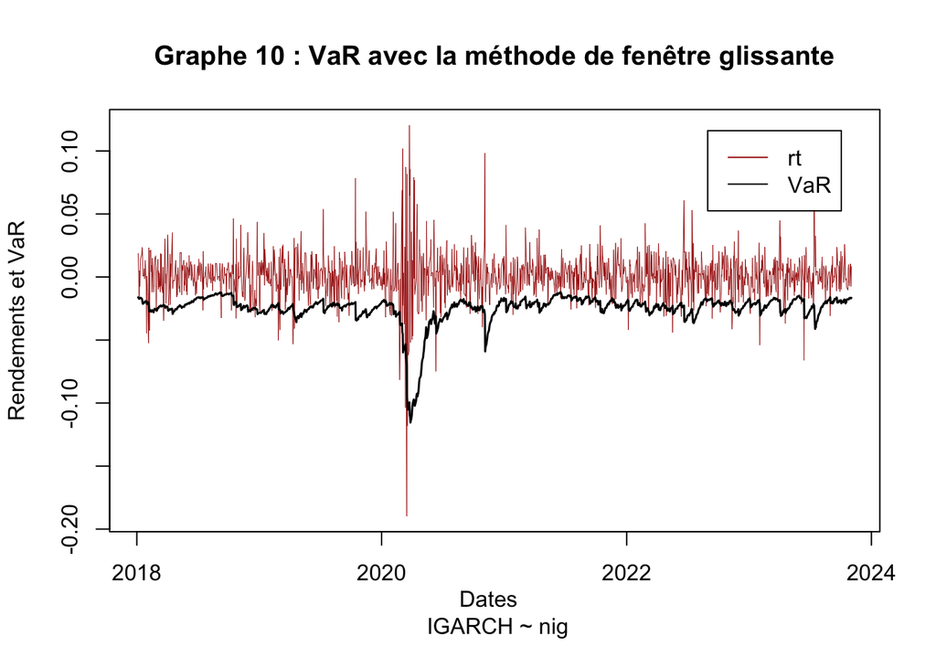

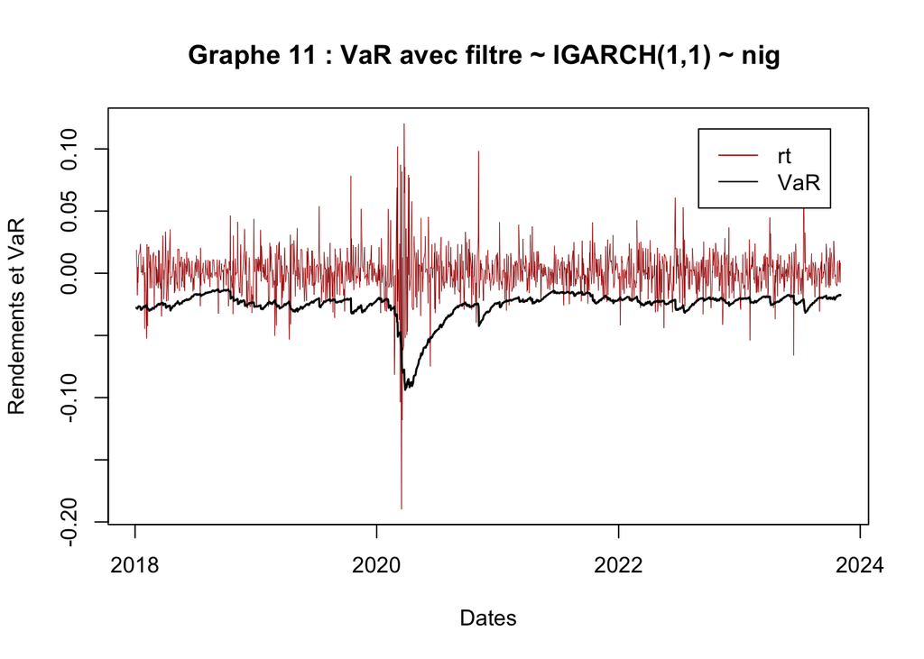

Table 5 : Violations VaR IGARCH(1,1)~nig

|  | Violation Estimée | Violation théorique | PV Kupiec | PV Christoffersen |
| --- | --- | --- | --- | --- |
| VaR IGARCH(1,1) ~ nig | 83 | 73.4 | 0.257 | 0.175 |

La VaR de notre modèle IGARCH présente un taux de violation de 5,7%. Nous avons donc ici sous-évalué la VaR de 0,7%. La p-value est supérieure à 0,05 dans le cadre du test de Kupiec. Ainsi, nous acceptons l’hypothèse nulle, indiquant que la VaR est bien estimée. De même, la p-value est supérieure à 0,05 dans le cadre du test de Christoffersen. Nous acceptons donc l’hypothèse nulle, confirmant que la VaR est bien estimée et que les violations sont indépendantes.

### b) GJR-GARCH(0,1) ~ std :

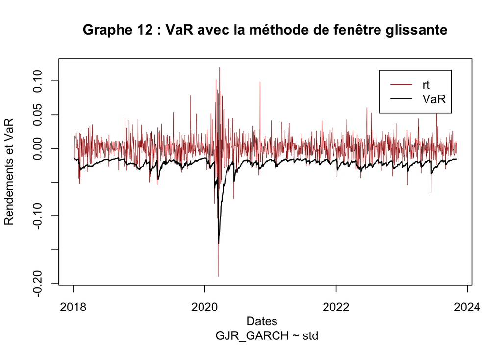

|  | Violation Estimée | Violation théorique | PV Kupiec | PV Christoffersen |
| --- | --- | --- | --- | --- |
| VaR GJR_GARCH(0,1) ~ std | 91 | 73.4 | 0.041 | 0.047 |

La VaR de notre modèle GJR_GARCH présente un taux de violation de 6,2%. Nous avons donc sous-évalué la VaR de 1,2%. La p-value est inférieure à 0,05 dans le cadre du test de Kupiec. Ainsi, nous rejetons H0, indiquant que la VaR n’est pas bien estimée. De même, la p-value est inférieure à 0,05 dans le cadre du test de Christoffersen, conduisant également au rejet de H0. La VaR n’est donc une fois de plus pas bien estimée selon ce test.

# Bibliographie :

- Cours de Madame Marie Lebreton
- https://www.unitedhealthgroup.com
- https://en.wikipedia.org/wiki/UnitedHealth_Group
- Time Series Analysis and Its Applications With R Examples (Springer Texts in Statistics) - Robert H. Shumway, David S. Stoffer